# 2016 Nebraska Presidential Election Contributions

Nathaniel Booth

Oct 2, 2017

# Introduction

This is Federal Election Commission [contribution data](http://fec.gov/disclosurep/PDownload.do) for the 2016 presidential election. It is limited to individual Nebraska contributors. This doesn’t include contributions made to or on behalf of candidates by businesses or political action committees (like the infamous Super PACs). Thus, this is an incomplete picture of the flow of money in Nebraska during this election.

### Background

The maximum that an individual can contribute during a single election is $2,700. Primaries and general elections are separated. So, an individual can contribute up to the maximum amount for the primary and general elections each, to reach a maximum of $5,400.

# Univariate Exploration

```
## 'data.frame':    27683 obs. of  17 variables:
##  $ cmte_id          : Factor w/ 22 levels "C00458844","C00500587",..: 14 14 14 6 14 6 7 6 6 11 ...
##  $ cand_id          : Factor w/ 22 levels "P00003392","P20002671",..: 21 21 21 1 21 1 12 1 1 14 ...
##  $ cand_nm          : Factor w/ 22 levels "Bush, Jeb","Carson, Benjamin S.",..: 21 21 21 4 21 4 18 4 4 14 ...
##  $ contbr_nm        : Factor w/ 7403 levels "'CALLAHAN, MICHAEL",..: 5267 5267 5267 6360 6224 691 4569 3370 3019 985 ...
##  $ contbr_city      : Factor w/ 515 levels " SAINT EDWARD",..: 348 348 348 348 215 348 269 269 348 348 ...
##  $ contbr_zip       : Factor w/ 3780 levels "","0","00000",..: 1048 1048 1048 796 1868 1724 2244 2256 469 459 ...
##  $ contbr_employer  : Factor w/ 2228 levels "","- SELECT -",..: 1662 1662 1662 879 1758 1758 2037 1662 1161 325 ...
##  $ contbr_occupation: Factor w/ 1695 levels "","911 DISPATCHER",..: 1328 1328 1328 1061 971 1047 998 1540 1424 106 ...
##  $ contb_receipt_amt: num  -80 -80 -80 77.5 124.8 ...
##  $ contb_receipt_dt : Date, format: "2016-10-06" "2016-10-13" ...
##  $ receipt_desc     : Factor w/ 10 levels "","REATTRIBUTION / REDESIGNATION REQUESTED",..: 1 1 1 1 1 1 1 1 1 1 ...
##  $ memo_cd          : Factor w/ 2 levels "","X": 2 2 2 2 2 2 1 2 2 1 ...
##  $ memo_text        : Factor w/ 26 levels "","$0.72 REFUNDED ON 10/25/2016",..: 1 1 1 6 1 6 3 6 6 3 ...
##  $ form_tp          : Factor w/ 3 levels "SA17A","SA18",..: 2 2 2 2 2 2 1 2 2 1 ...
##  $ file_num         : int  1146165 1146165 1146165 1091718 1146165 1091718 1077404 1091718 1091718 1144666 ...
##  $ tran_id          : Factor w/ 27639 levels "A009F9A20369B4F0E852",..: 19041 19042 19043 7317 21035 7288 23450 7276 7320 27638 ...
##  $ election_tp      : Factor w/ 4 levels "","G2016","O2016",..: 2 2 2 4 2 4 4 4 4 4 ...
```

The dataset has mostly factor variables, but contributions are numbers. I removed the state variable because it is constant for all rows. I converted the committee ID from character to string. If I use it later, then I anticipate it to be more useful in this form. I converted the receipt date of a contribution to a date object. Maybe I’ll find some interesting clustering of contributions in time.

#### Initial Questions and Thoughts

- Are certain employers overrepresented?
- Are certain occupations overrepresented?
- It might be useful to create a new variable that assigns party alignment for each candidate.
- Apparently, there were 22 different candidates in the primaries. I think I’ll winnow that list down to the candidates who matter. I’ll probably use a rule based on how many contributions received or the total dollar amount received.
- What is the amount contributed to Democrats and Republicans?
- Are contributor locations (by city or zip code) overrepresented?
- Gender might be an interesting variable to add, but it would be a pain to find and compare the names to some other public dataset (like voting records) in order to assign a gender. Even then, I couldn’t guarantee that it’s the same person and not another person with the same name.
- Which candidates received the most amount of contributions?
- How much money did candidates receive?

#### Add Political Party Variable

```
##     D     G     I     L     R
## 16953    20    10    91 10609
```

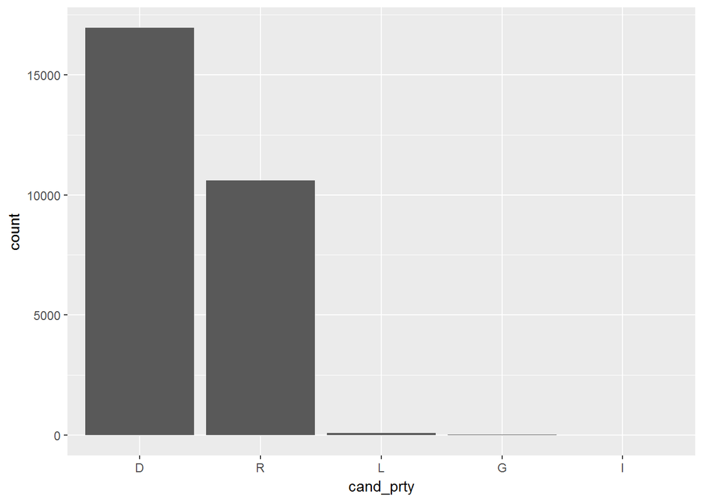

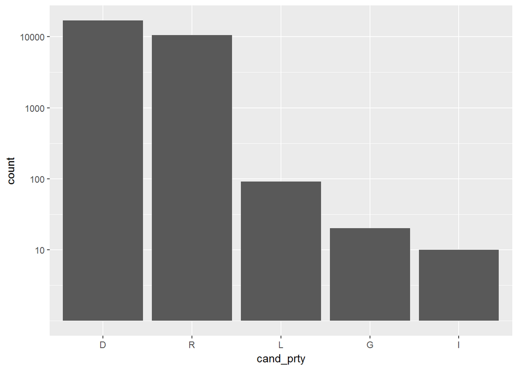

[output not shown]

```r
ggplot(aes(x = cand_prty),
       data = sortedParty) +
    geom_bar() +
    scale_y_log10(breaks=c(10,100,1000,10000))
```

The main features of interest are the candidates and the contribution amounts. Supportive features include contributor attributes (location, occupation, employer) and contribution dates.

Two election type contributions are classified as *Other*. I have no idea what that could be.

#### Distribution of Contribution Amounts

```r
summary(ne$contb_receipt_amt)
```

```
##     Min.  1st Qu.   Median     Mean  3rd Qu.     Max.
## -4600.00    19.00    28.00    88.44    80.00  5400.00
```

The contribution amount variable has outliers on both sides of the data. On the left side, outliers are from refunds. On the right, outliers are from maximum allowed donations. Let’s remove the [top and bottom 1%](http://r.789695.n4.nabble.com/removing-lower-and-upper-quantiles-from-an-arry-td3310479.html) and view.

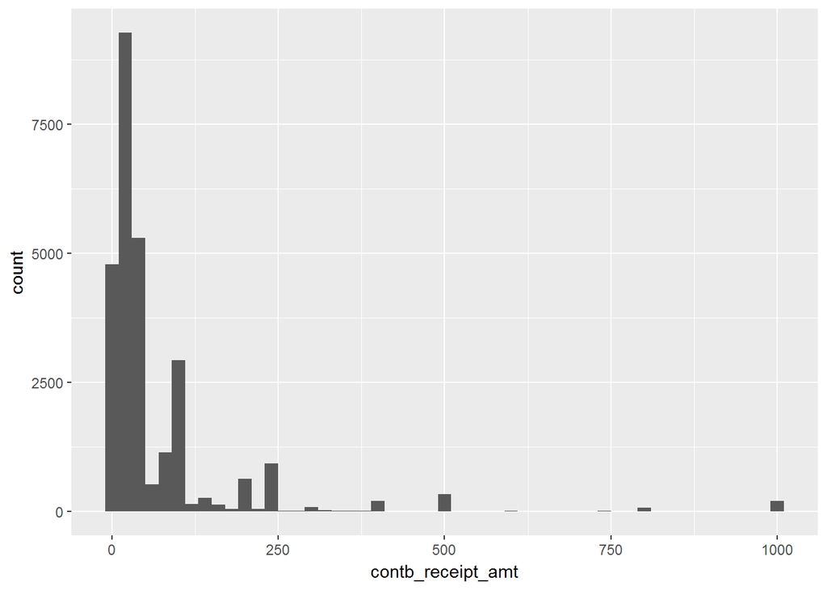

It looks like most contributions are at the lower end of the scale, $250 or less.

I’ve heard from past reading and news consumption that since Barack Obama’s 2008 campaign, campaigns have seen a large uptick in the number of small individual contributions. In this case, most are below $250. Let’s take a closer look at those contributions.

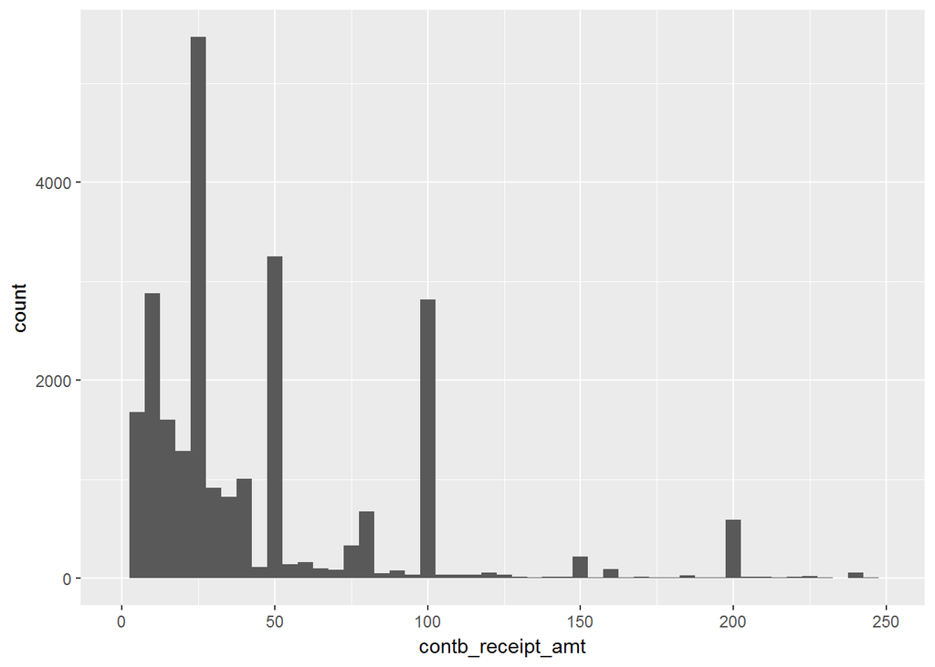

So, small amounts and easy denominations are popular, such as $25, $50, and $100. What about if we look at less than $100 contributions?

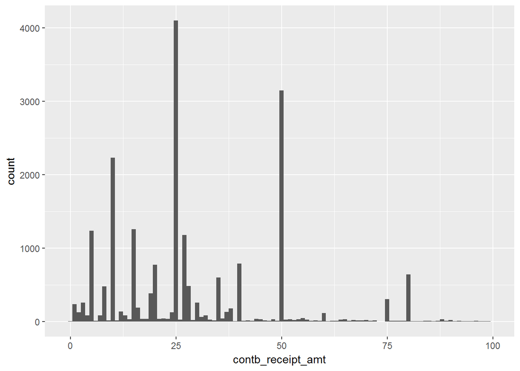

This looks like confirmation of the tendency to contribute in multiples of 5, like $5, $10, $15, etc. $10, $25, and $50 demoninations are the most popular.

#### Locations of Contributors

```
##        OMAHA      LINCOLN     BELLEVUE    PAPILLION      ELKHORN
##         9227         6510         1063          604          428
##      KEARNEY GRAND ISLAND NORTH PLATTE      FREMONT     HASTINGS
##          419          407          356          317          308
##  SCOTTSBLUFF      NORFOLK     COLUMBUS        BLAIR   BENNINGTON
##          241          239          226          205          184
##     LA VISTA  PLATTSMOUTH         YORK       NORMAN      (Other)
##          177          163          130          118         6361
```

Most contributions come from Omaha and Lincoln. Some of these locations qualify as [villages](https://en.wikipedia.org/wiki/Village) and hamlets. I wonder for some of these locations how the political contribution rate compares to that of a town or city. I won’t delve into an answer here.

```
##     OMAHA
## 0.5684716
```

Ignore the “OMAHA” label above - I couldn’t find a way to remove it. Omaha and Lincoln account for about 57% of the contributions. Let’s visualize this.

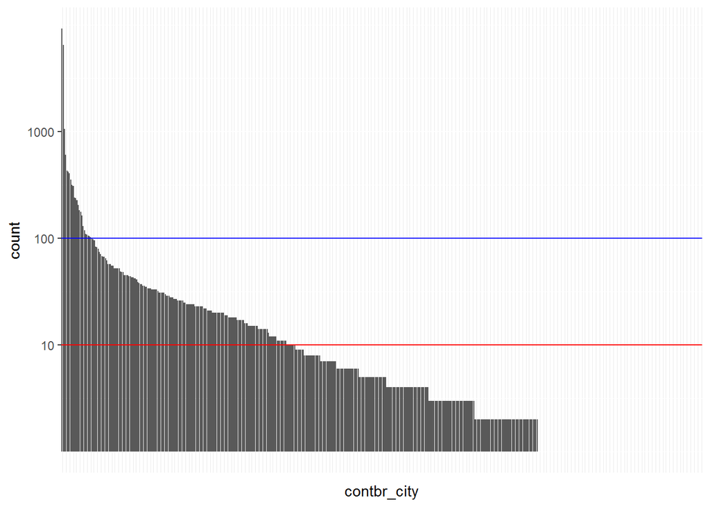

Three cities, Omaha, Lincoln, and Bellevue, each have over 1000 contributions. Some cities have over a hundred. The vast majority have 100 or less contributions. Let’s [reduce](https://discussions.udacity.com/t/subsetting-candidates/231047) how many cities we’re viewing to cities whose residents made over 500 contributions.

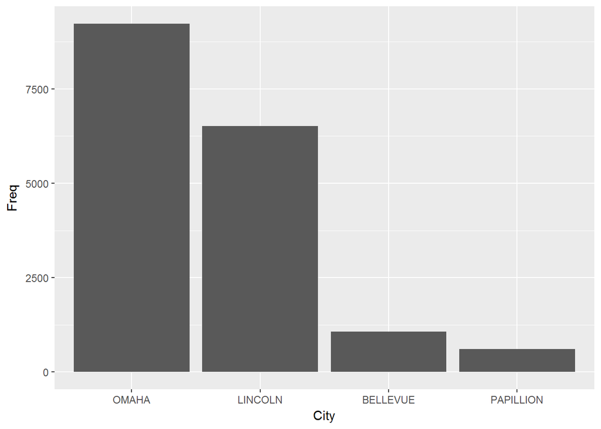

The top three contributing cities also have the largest populations. Papillion and Bellevue are within Omaha’s metro area. It seems like the number of contributions is a function of population.

#### Contribution Recipients

```
## Clinton, Hillary  Sanders, Bernie    Trump, Donald        Cruz, Ted
##            10377             6542             4838             2610
##      Carson, Ben     Rubio, Marco          (Other)
##             2383              324              609
```

It looks like at least three levels exist here. Clinton received over two times the number of contributions compared to Trump. Sanders fell between the two. Trump had about two times the number of contributions compared to Cruz and Carson. Cruz and Carson had at least seven times the number of contributions compared to the remaining candidates with Rubio coming the closest.

```
## Clinton, Hillary
##        0.6111693
```

Ignore the Clinton label above, I couldn’t remove it. Clinton and Sanders accounted for about 61% of the total contributions. This is somewhat surprising for an overall conservative state, but recall that the metro areas accounted for about 57% of the contributions. Cities tend to be more liberal and vote Democrat, so this isn’t surprising after all.

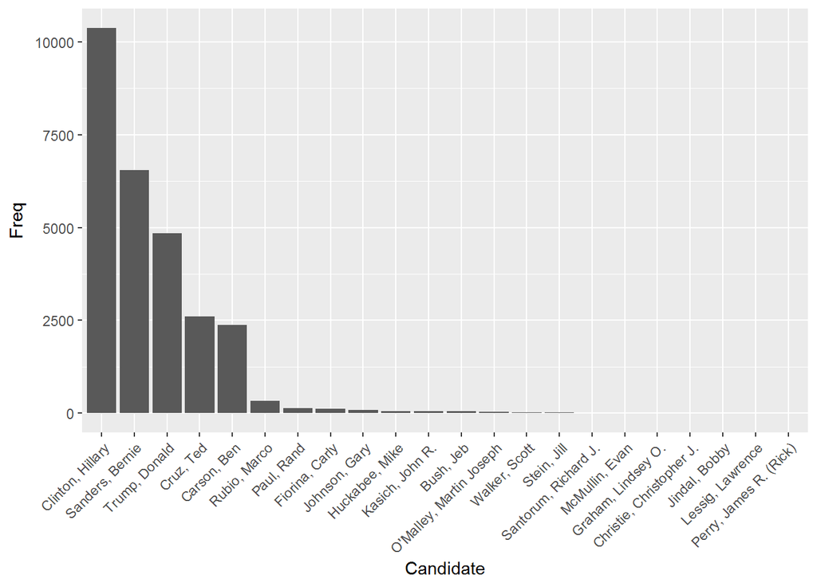

You get a good sense of the level of candidate support among the population of individual contributors in Nebraska. This frequency data spans four orders of magnitude so let us get a scale look at it.

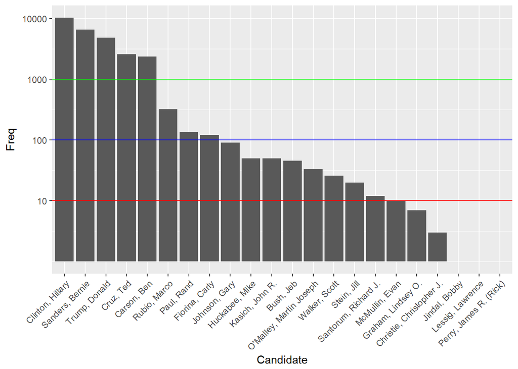

```r
ggplot(cand_count[cand_count$Freq > 0,], aes(x=Var1,y=Freq)) +
    geom_bar(stat="identity") +
    theme(axis.text.x = element_text(angle=45, hjust = 1)) +
    xlab("Candidate") +
    scale_y_log10(breaks=c(10, 100, 1000, 10000)) +
    geom_hline(yintercept=10, color = 'red') +
    geom_hline(yintercept=100, color = 'blue') +
    geom_hline(yintercept=1000, color = 'green')
```

Five candidates received over 1000 individual contributions from Nebraskans.

# Univariate Analysis

##### *What is the structure of the dataset?*

The dataset contains mostly factor variables. Contribution amounts are numbers.

##### *What is/are the main feature(s) of interest in your dataset?*

The main primary features are the candidates and their received contributions.

##### *What other features in the dataset do you think will help support your investigation into your feature(s) of interest?*

The secondary features are contributor attributes, like location (stored as a city or zipcode), occupation, employer, and contribution receipt date. The receipt date is probably the most noisy variable because it is unknown what the difference is between when the contributor made the contribution and when it was received, processed, and recorded. But it may prove an interesting if rough proxy for viewing spikes in contributions over time.

##### *Did you create any new variables from existing variables in the dataset?*

I created a variable for political party for each candidate as a supporting feature.

##### *Of the features you investigated, were there any unusual distributions? Did you perform any operations on the data to tidy, adjust, or change the form of the data? If so, why did you do this?*

I changed the receipt date from factor to date type so that I can possibly make a timeline later. The dataset was clean so I didn’t do any tidying.

# Bivariate Exploration

#### Contributions Over Time

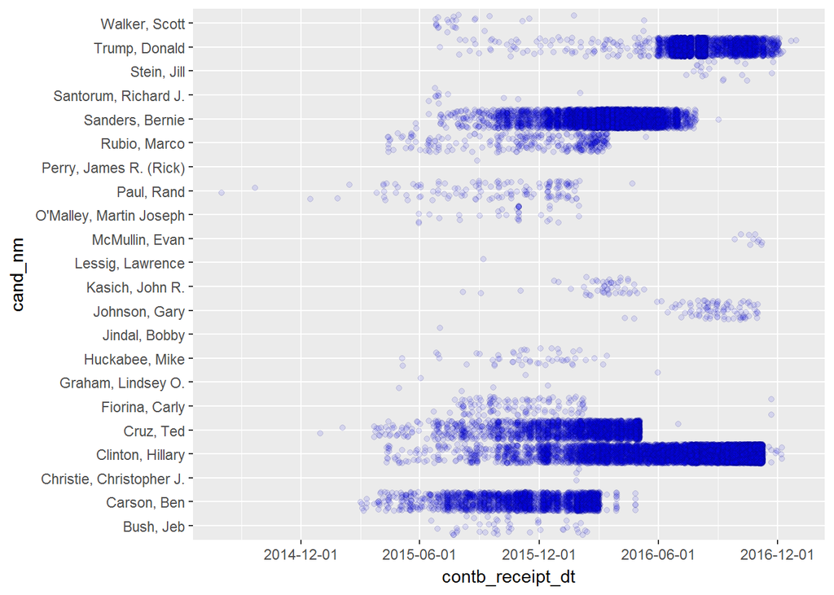

This reveals the number of contributions a candidate received over the two elections. Trump, Sanders, Cruz, Clinton, and Carson (with Rubio on the boundary), all had supporters who contributed often. This is a bit crowded though because some candidates hardly received contributions.

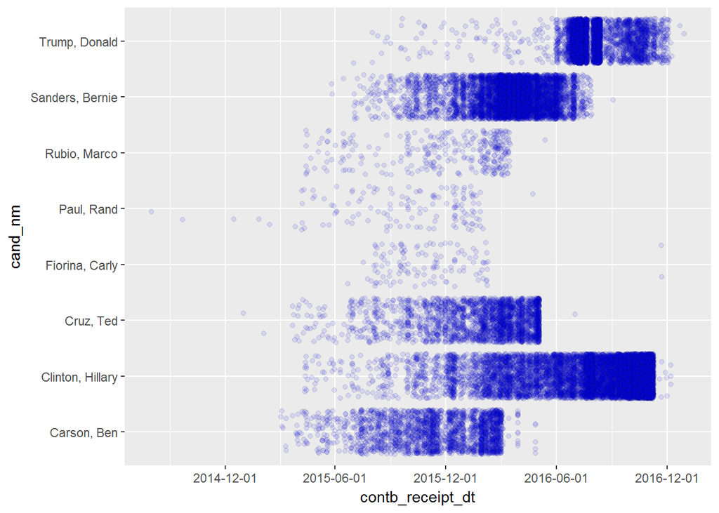

Here we see candidates who received over 100 contributions. This eliminates 14 candidates. Interestingly, by the density of the plot, it looks like Trump’s contributions decreased as the general election progressed. I wonder if his supportors became less enthusiastic, supporters gave less often, or Trump didn’t earn new supporters.

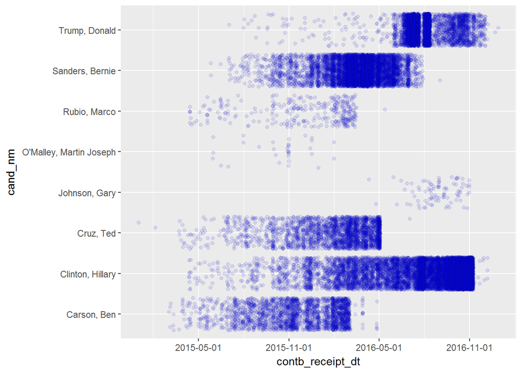

This is a graph of candidates who received more than 5 contributions on some receipt date. I do not think this has much value. The receipt date is already a rough lagging proxy for support at some point in time. The data set did not indicate whether the receipt date is when the contributor made the contribution or when it was processed by the committee. Thus, this could say more about when the committee processed its received contributions than when a candidate received monetary support.

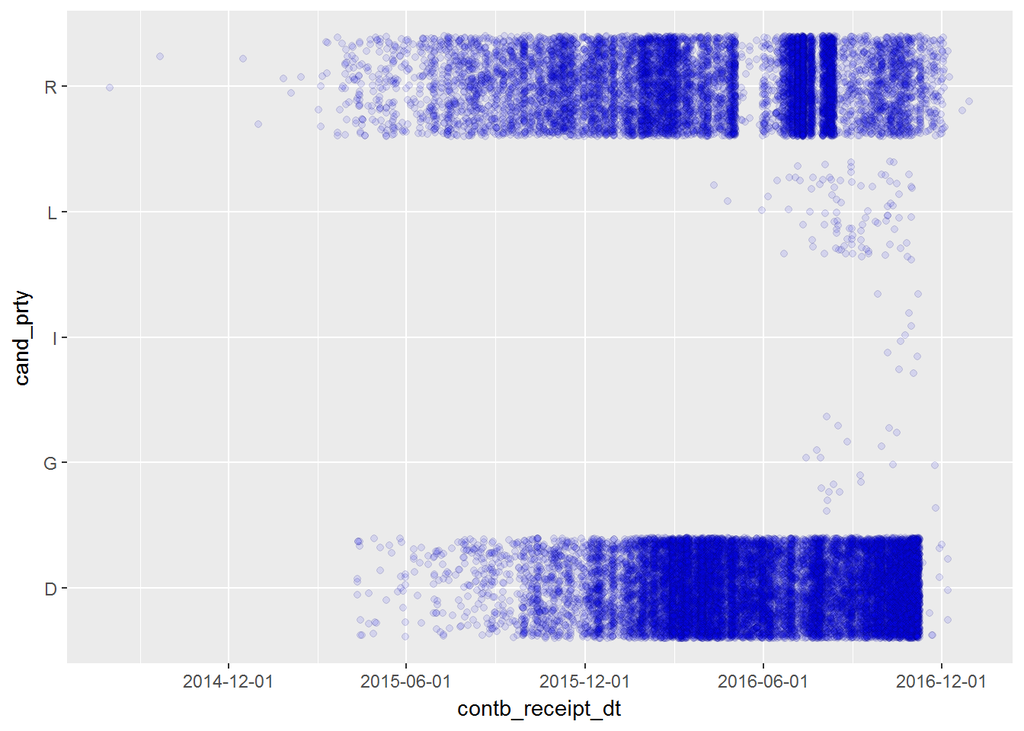

Number of contributions to party candidates over time. It looks like the Republican candidate lost some support towards the end of the election. The Democrats had a mostly steady increase of contributions that sustained through 2016. The third party candidates garnered support during the general election. My hypothesis is that primary voters’ ideal candidates did not win their respective primaries, so they migrated to these other candidates.

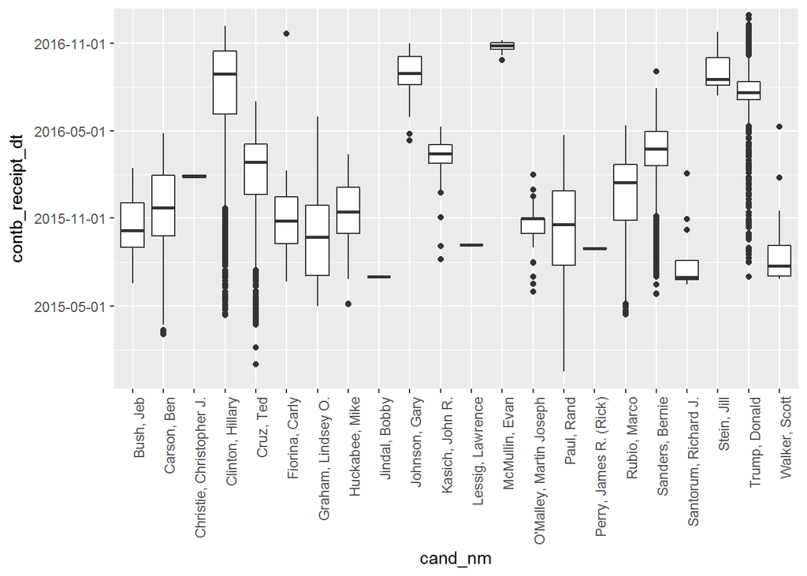

Here we can see the periods of time over which candidates received individual contributions. Outliers below their respective boxplots are early supporters of candidates. Clinton, Cruz, Sanders, and Trump had many early adopters. Some candidates earned support once the general election began as alternatives to Clinton and Trump. Some candidates were hardly considered, like McMullin, Stein, Christie, Perry, Lessig, and Jindal), and the late arrivals (Stein, McMullin, and Johnson).

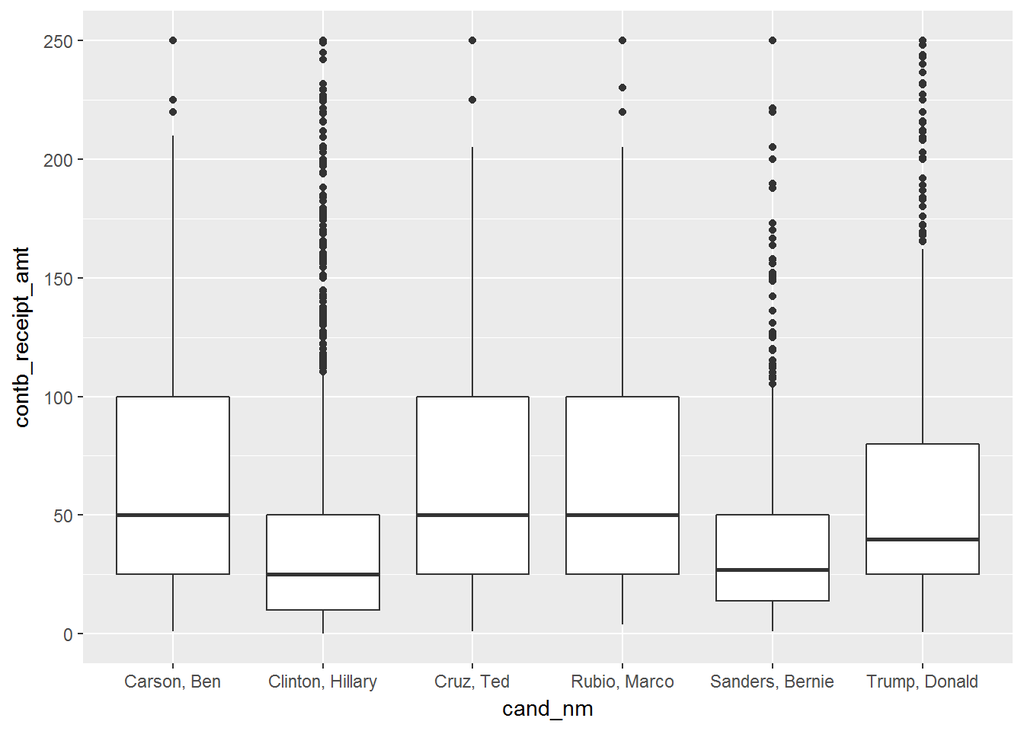

A boxplot summary of contribution amounts by candidate. I eliminated the negative contributions, which I assume are returned contributions, and amounts over $250. This only includes candidates who received over 250 contributions. This clearly shows the typical range of contributions and that candidates received many outliers. Interestingly, the Republican candidates had higher interquartile ranges and medians compared to Democratic candidates. This could be an indicator that Republican supports are more affluent or more invested in their candidates.

# Bivariate Analysis

##### *Talk about some of the relationships you observed in this part of the investigation. How did the feature(s) of interest vary with other features in the dataset?*

Two relationships are interesting here.

- Clinton and Sanders received lower median amounts of contributions compared to Republican candidates ($25 to $50).
- The campaign began in 2015, but most candidates did not gain much financial support from individual Nebraska contributors until 2016.

##### *Did you observe any interesting relationships between the other features (not the main feature(s) of interest)?*

I haven’t made use of supporting features yet.

##### *What was the strongest relationship you found?*

Democrats received smaller contributions than Republican candidates.

# Multivariate Exploration

## Once More, With Color

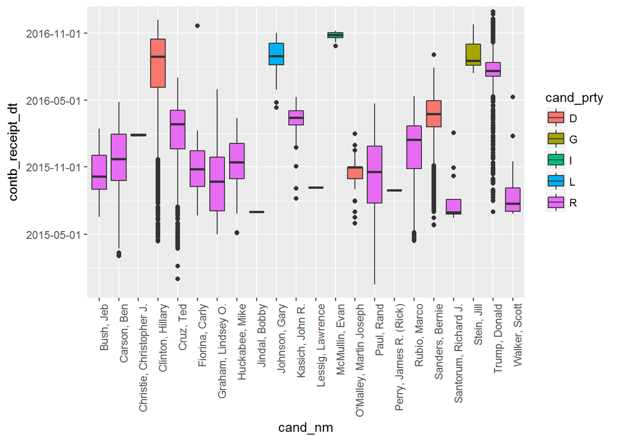

Here it is easy to see that third party candidates gathered support as the primaries ended or afterward. It’s indicative that supporters of losing primary candidates migrated to third party candidates.

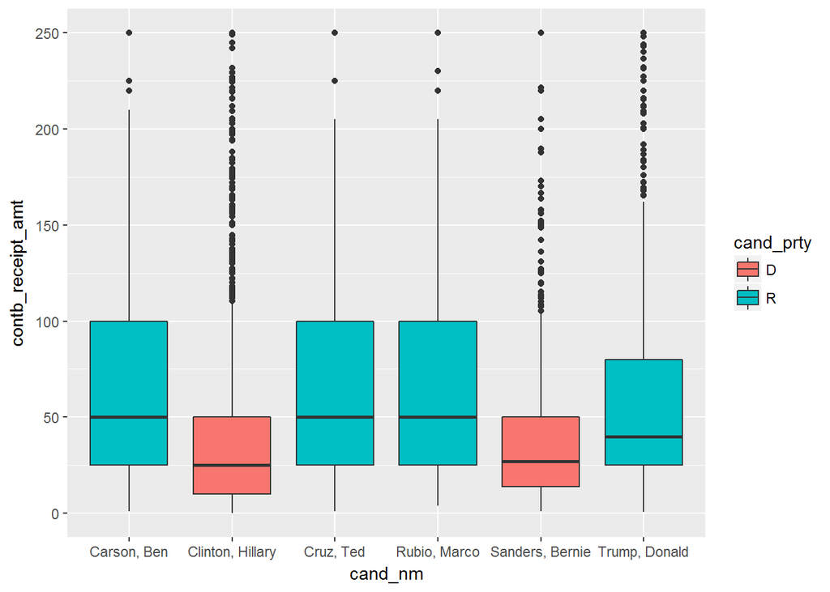

Here I have made more obvious the difference in amounts that Republicans and Democrats received in contributions.

In the horse race of financial contributions, who is winning?

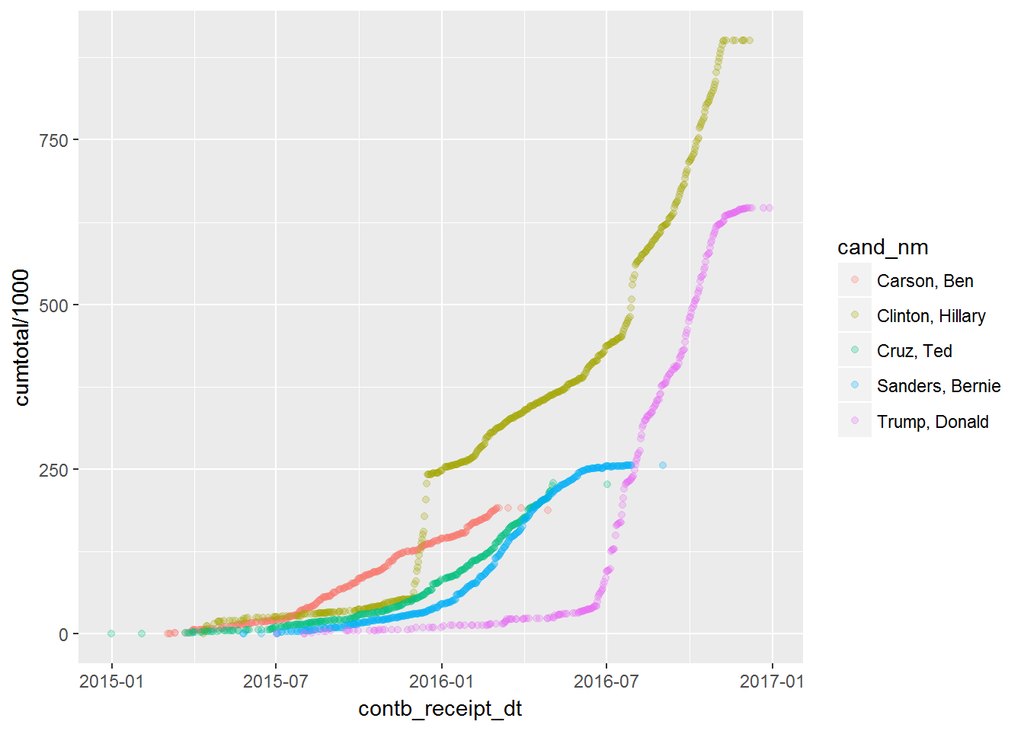

# Multivariate Analysis

##### *Were there any interesting or surprising interactions between features?*

These results weren’t surprising after seeing the initial data summaries showed that Clinton received many more contributions relative to other candidates than I expected.

##### *OPTIONAL: Did you create any models with your dataset? Discuss the strengths and limitations of your model.*

Not at this time. I’d like to do a logistic regression or decision tree to see if contributor attributes (city, zip, employer, occupation) can be used to predict candidate or party support.

# Final Plots and Summary

### Plot One

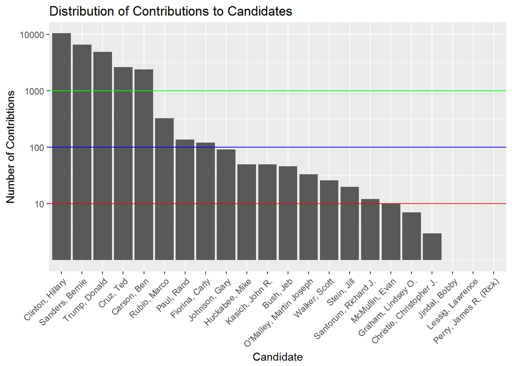

### Description One

This histogram visualizes the first surprising facts.

1. Hillary Clinton received more individual contributions during the primary and general elections than other candidates.
2. The two major Democratic candidates received more contributions than any Republican candidates.

### Plot Two

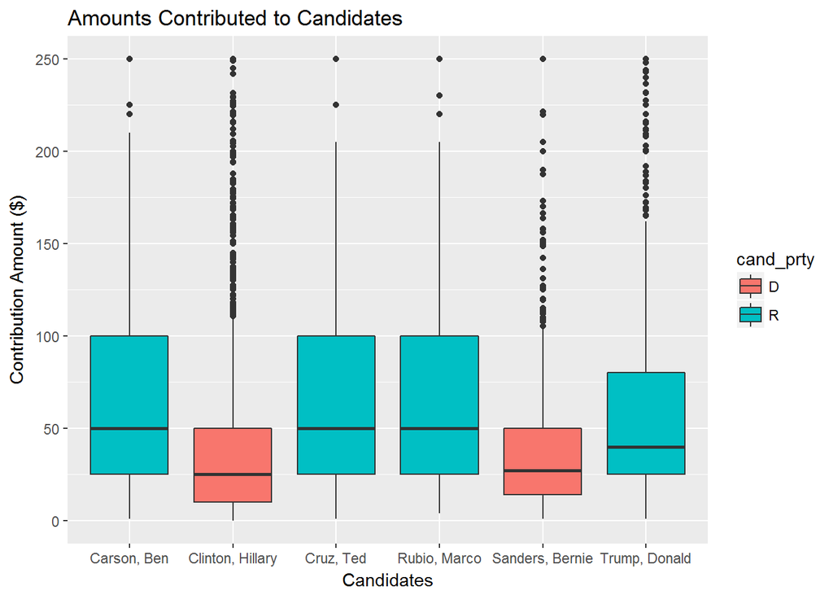

### Description Two

This plot of boxplots shows that the Democratic candidates received lower contributions amounts compared to Republican candidates. The median values for Democrats are about half what Republicans received. It shows a lot of outliers with more in favor of the Democrats.

### Plot Three

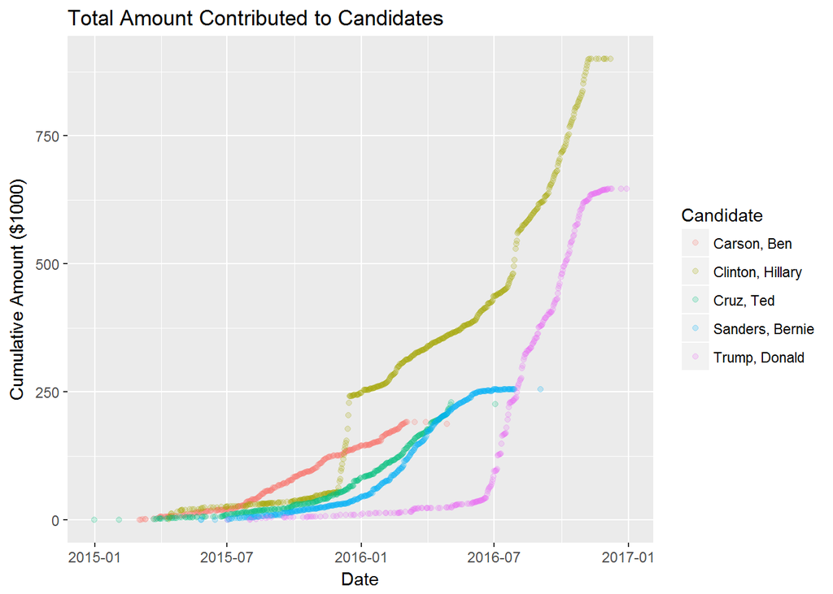

### Description Three

This line plot contains three interesting revelations.

1. Clinton was always ahead of Sanders in the primary and Trump in the general.
2. Trump started to get serious monetary support during the general election.
3. Carson and Cruz received more contributions than Trump during the primary.

# Reflection

### Difficulties

My toughest time was with cleaning the data with dplyr and tidr (e.g., grouping or spreading). Arranging the data for visualizing the cumulative sum of contributions was sticky. I had trouble deciding what to do about the thin data on occupations and employers. I elected not to use it here.

### Successes

Right away, during my overview of the data, I was surprised to see how many contributions Clinton and received compared to other candidates. If the voting population matched the voting district population and the individual contributor population, then one would expect Clinton to have won the 2nd voting district (i.e. the Omaha metro) in the general election. She did not, this implies those popualtions are not the same. The cumulative sum and boxplots turned out great. They both reveal several ideas to the audience.

### Future Work

I would like to map zipcodes to a heatmap of Nebraska so that we can see where candidate or party support is coming from. It would be interesting to compare that heatmap to ones created from previous elections. My intuition would be to expect Democratic contributions from urban areas and Trump support from rural and suburban areas in this mostly conservative state, but maybe a surprise is in store.

I want to see if occupation or employer is predictive of the amount a person contributes to a candidate, which candidate a person contributes to, or which party one contributes to.

### Resources

1. [row.names error](https://stackoverflow.com/questions/13239639/duplicate-row-names-error-reading-table-row-names-null-shifts-columns/22408965#22408965)
2. Udacity LiveHelp Mentors helped with tidyr and dplyr
3. [ggplot2 syntax](http://ggplot2.tidyverse.org)
4. [replacing row values](https://stackoverflow.com/questions/13871614/replacing-values-from-a-column-using-a-condition-in-r)
5. [ordering factors](https://stackoverflow.com/questions/5208679/order-bars-in-ggplot2-bar-graph)
6. [adding horizontal lines](https://stackoverflow.com/questions/10748180/add-horizontal-line-to-ggplot)